## **Burrowing bettong**

### Blamed on cats

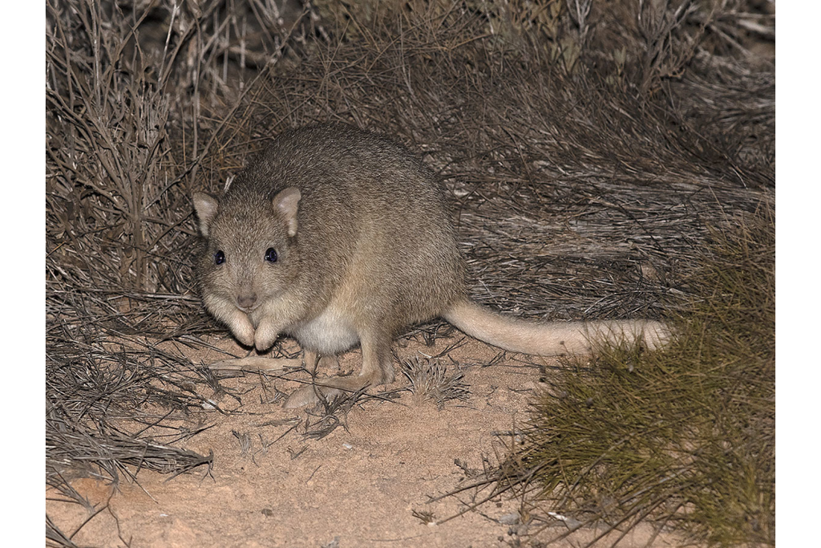

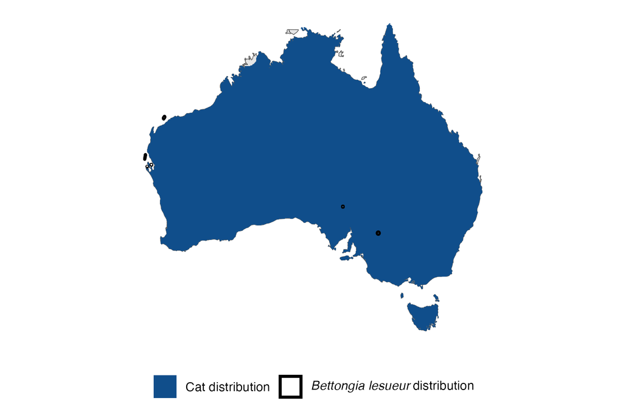

IUCN status: **Near Threatened**

EPBC Predator Threat Rating: **Moderate**

IUCN claim: *“Feral cats are a proven threat to this species”*

### Studies in support

Cats were the main predator, or a predator, of predator-inexperienced (where known) reintroduced bettongs (Christensen & Burrows 1995; Short & Turner 2000; Moseby et al. 2011; Moseby et al. 2018; Moyses et al. 2020). Cats hunted bettongs in fenced reserve (Moseby et al. 2019). Bettongs were last confirmed in Victoria, NSW (2 records), southwest WA (2 records), Nullarbor, and Charleville 3-33, 2-72, 80-112, 38-58, and 35-45 years after cats arrived, respectively (Wallach and Lundgren 2025).

### Studies not in support

A positive correlation was found between cat and bettong abundance within a fenced reserve, despite evidence of hunting, and bettong recruitment was confirmed (Moseby et al. 2019). A cat breached the fence of a semi-captive bettong enclosure, yet none were hunted in 1 month (from Moseby et al. 2015). Bettongs were last confirmed in the Murray-Darling 24 years before, to 17 years after, cats arrived (Wallach and Lundgren 2025).

### Is the threat claim evidence-based?

No studies were found evidencing a negative association between cats and burrowing bettong populations. The fate of reintroduced animals is not a proxy for the fate of locally-born populations. In one region it cannot be verified that extirpation occurred after cat arrival, and in one region the two species possibly co-occurred for over a century before extirpation.

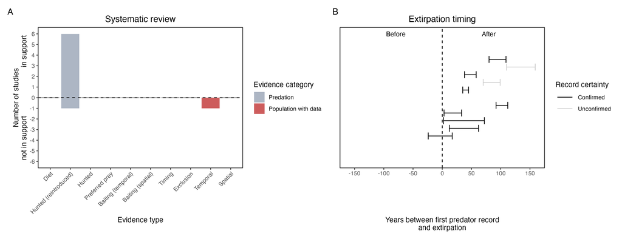

**Evidence linking *Bettongia lesueur* to cats.** **A.** Systematic review of evidence for an association between *Bettongia lesueur* and cats. Positive studies are in support of the hypothesis that cats contribute to the decline of *Bettongia lesueur*, negative studies are not in support. Predation studies include studies documenting hunting or scavenging; baiting studies are associations between poison baiting and threatened mammal abundance where information on predator abundance is not provided; population studies are associations between threatened mammal and predator abundance. Gold borders indicate studies that meet qualities of scientific rigour. **B.** Last records of extirpated populations relative to earliest local records of cats. Error bars show minimum and maximum extinction intervals. Predator arrival records were digitized from Abbott 2008. See methods section in Wallach and Lundgren 2025 for details on evidence categories.

### References

Abbott, The spread of the cat, Felis catus, in Australia: re-examination of the current conceptual model with additional information. Conservation Science Western Australia 7 (2008).

Christensen, P. and Burrows, N., 1995. Project desert dreaming: experimental reintroduction of mammals to the Gibson Desert, Western Australia. Reintroduction Biology of Australian and New Zealand Fauna’.(Ed. M. Serena.) pp, pp.199-207.

EPBC. (2015) Threat Abatement Plan for Predation by Feral Cats. Environment Protection and Biodiversity Conservation Act 1999, Department of Environment, Government of Australia. (Table A1).

IUCN Red List. https://www.iucnredlist.org/ Accessed June 2023

Moseby K, Peacock D, Read J. 2015. Catastrophic cat predation: a call for predator profiling in wildlife protection programs. Biological Conservation 191:331-340.

Moseby, K.E., Letnic, M., Blumstein, D.T. and West, R., 2018. Designer prey: can controlled predation accelerate selection for anti-predator traits in naïve populations?. Biological Conservation, 217, pp.213-221.

Moseby, K.E., Letnic, M., Blumstein, D.T. and West, R., 2019. Understanding predator densities for successful co‐existence of alien predators and threatened prey. Austral Ecology, 44(3), pp.409-419.

Moseby, K.E., Read, J.L., Paton, D.C., Copley, P., Hill, B.M. and Crisp, H.A., 2011. Predation determines the outcome of 10 reintroduction attempts in arid South Australia. Biological Conservation, 144(12), pp.2863-2872.

Moyses, J., Hradsky, B., Tuft, K., Moseby, K., Golding, N. and Wintle, B., 2020. Factors influencing the residency of bettongs using one‐way gates to exit a fenced reserve. Austral Ecology, 45(7), pp.858-871.

Short, J. and Turner, B., 2000. Reintroduction of the burrowing bettong Bettongia lesueur (Marsupialia: Potoroidae) to mainland Australia. Biological Conservation, 96(2), pp.185-196.

Wallach A.D., Lundgren E.J. (2025) Review of evidence that foxes and cats cause extinctions of Australia’s endemic mammals. BioScience. DOI: 10.1093/biosci/biaf046